# Praca Domowa 4

Paweł Wicherek

4/16/2020

Modelujemy ceny mieszkań w Seattle, KC. Mamy do dyspozycji następujące zmienne:

Dodatkowo dodaliśmy jeszcze również dwie inne zmienne przestrzenne: * liczbę obiektów kulturalnych w promieniu 1km (`ncult`), * dystans do najbliższego przystanku (`dist_stop`).

Dane pozyskano ze strony: **data.seattle.gov.pl**. W załączniku znajdują się 3 skrypty pozwalające dodać te zmienne.

Próbujemy znaleźć obserwacje, które mają różne profile CP. Przykładem są losowo wybrane `6386`, `3560` (przy pomocy `sample(N,2)`). Podejrzyjmy zmienne położenie geograficzne, `long` i `lat`.

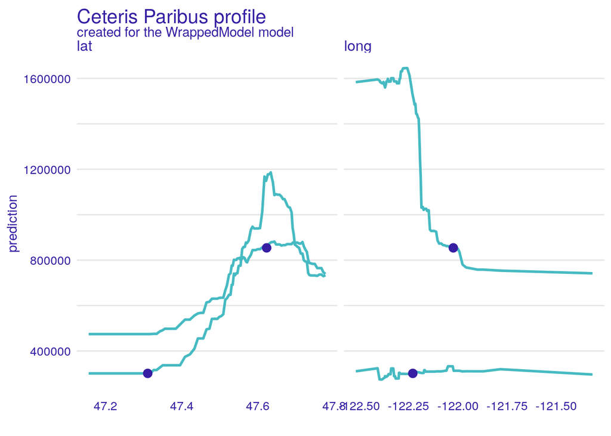

Dla jednej obserwacji wływ `long` jest bardzo istotny. Okazuje się, że droższa obserwacja leży zdecydowanie bardziej na wschód. Od Seattle dzielą ją dwa jeziora, które trzeba objechać próbując dostać się do centrum miasta. Zyskałaby jeszcze więcej, jeśli byłaby bardziej ,,na lewo’’. Tańsza obserwacja to niewielki domek sprzed stu lat na południe od miasta. Przesunięcie jej lewo/prawo niewiele zmieni, za to zyskałaby zdecydowanie, gdyby była wybudowana bardziej na północ, w centrum.

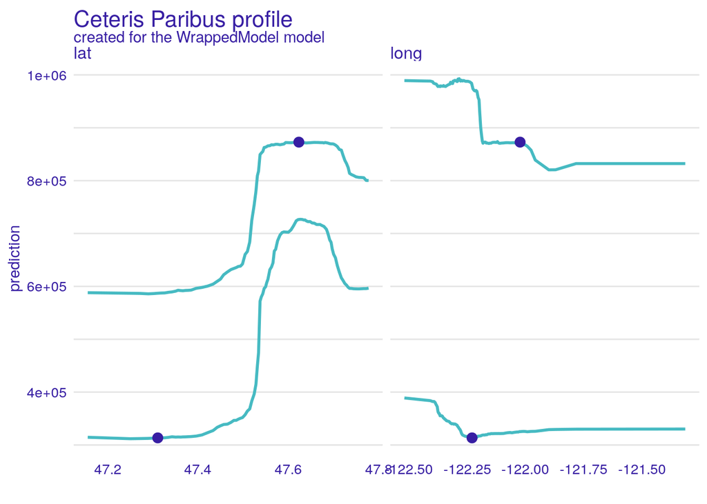

# Załączynik

## Dodanie zmiennych przestrzennych.

Użyliśmy procedurki, która daje szybkie i bardzo dobre przybliżenie odległości między punktami. Daje niewielki błąd na bardzo małym obszarze, jak np województwo, czy miasto. Dla dystansów większych trzeba korzystać już z pakietu geopy.

```python
"""geofast.py"""
import math
import numpy as np

def _dist(lon1,lat1,lon2,lat2):
    """
    Very fast computation for distance between (lon1,lat1)
    and (lon2,lat2) providing the locations are not so far
    away, i.e. in one city.

    Parameters:
        lon1 : float
            Longitude of the first point
        lat1 : float
            Latitude of the first point
        lon2 : float
            Longitude of the second point
        lat2 : float
            Latitude of the second point

    Returns: int
        Distance in meters between (lon1,lat1) and (lon2,lat2)

    """
    dy = 111134 *(lat2-lat1)
    dx = 111317*(lon2-lon1)*math.cos((lat1+lat2)/2)
    return int(math.sqrt(dx**2+dy**2))

distance = np.vectorize(_dist)
""" vectorized for only for (lon1,lat1)~series(lon2,lat2)
or
series(lon1,lat1)~(lon2,lat2)
"""
```

Powyższej procedurki używamy do utworzenia zmiennych `dist_stop` oraz `ncult` przy pomocy skryptów pythonowych:

```python
import pandas as pd
import os
import geofast

os.chdir("/home/wicherekp/Py/xai/")

houses = pd.read_csv("kc_house_data.csv")
stops = pd.read_csv("./trans1/stops.txt")

def _find_closest(nth_row):
    # houses ← ramka domów
    # stops ← ramka przystanków
    h = houses.loc[nth_row,["long","lat"]]
    return geofast.\
        distance(h.long,h.lat,
                 stops.stop_lon,stops.stop_lat)\
        .min()

N = houses.shape[0]
houses["dist_stop"] = 2020

for h in range(N):
    houses.loc[h,"dist_stop"] = _find_closest(h)

houses.dist_stop
houses.to_csv("houses+stops_0304.csv",index=False)
```

oraz dla `ncult`:

```python
import pandas as pd
import os
import psutil
import geofast


os.chdir("/home/wicherekp/Py/xai/")

cult = pd.read_csv("cultural.csv")

cult = cult.Location.str[1:-1].str.split(", ",expand=True)
cult.columns=["lat","long"]
cult.lat = cult.lat.astype(float)
cult.long = cult.long.astype(float)
cult=cult.dropna().reset_index(drop=True)

houses = pd.read_csv("houses+stops_0304.csv")

houses.date = (houses.date.str[0:8]).astype(int)

N = houses.shape[0]
houses["ncult"] = 0



for i in range(N):
    h = houses.loc[i,["long","lat"]]
    h500 = geofast.distance(cult.long,cult.lat,h.long,h.lat)
    houses.ncult[i] = sum(h500<1000)

# znajdź duplikaty
idiki = houses.groupby("id").size()
duplicates = idiki[idiki>1].index

df = houses = houses.set_index("id") # checkpoint
# single
indexes_to_keep = set(df.index)-set(duplicates)
df = df.loc[indexes_to_keep,:]


for dup in duplicates:
    x = houses.loc[dup,:]
    x.price[0]=int(x.price.mean())
    x=x.iloc[0,:]
    df = df.append(x)

df.to_csv("final.csv")


from sklearn.model_selection import train_test_split

df_train,df_test=train_test_split(df,test_size=0.3)
df_train.shape
df_test.shape

df_train.to_csv("kc_train.csv")
df_test.to_csv("kc_test.csv")
```

Trzeba było jeszcze wprowadzić pewne poprawki, zatem

```python
import pandas as pd
import os
import psutil
import geofast

def usage():
    # just some function to check memory usage by Python
    process = psutil.Process(os.getpid())
    return process.memory_info()[0] / float(2**20)
usage()

os.chdir("/home/wicherekp/Py/xai/")


df_train = pd.read_csv("kc_train.csv")
df_test = pd.read_csv("kc_test.csv")

df = df_train.append(df_test)


df.info()

df.waterfront = df.waterfront.astype('category')
df.zipcode = df.zipcode.astype('category')

df["age"] = 2015- df.yr_built
df["since_renovated"] = 2015-df[["yr_built","yr_renovated"]].max(axis=1) #by rows
df.columns
df.info()

sqft_to_m2 = 0.092903
df["m2_living"] = df.sqft_living*sqft_to_m2
df["m2_lot"] = df.sqft_lot*sqft_to_m2
df["m2_above"] = df.sqft_above*sqft_to_m2
df["m2_basement"] = df.sqft_basement*sqft_to_m2
df["m2_living15"] = df.sqft_living15*sqft_to_m2
df["m2_lot15"] = df.sqft_lot15*sqft_to_m2
df = df.drop(["sqft_living","sqft_lot",
              "sqft_living15","sqft_lot15",
              "sqft_above","sqft_basement"],axis=1)
df.info()
df = df.set_index("id")
df
import seaborn as sns; sns.set()
sns.kdeplot(df.lot)
sum(df.m2_lot>10)
df.shape


from sklearn.model_selection import train_test_split

df_train,df_test=train_test_split(df,test_size=0.3)
df_train.shape
df_test.shape

df_train.to_csv("kc_train_2.csv")
df_test.to_csv("kc_test_2.csv")
```